# Introduction to generalized linear models with R

```r
  library(tidyverse)
  library(viridis)
  library(knitr)
  library(gtsummary)
  library(sjPlot)
  library(patchwork)
  library(ggrain)
  library(performance) # https://easystats.github.io/performance/
  library(lmtest)
  library(broom)
  library(faux) # https://debruine.github.io/project/faux/
```

```r
# Set colors/theme for plots

  col1 <- viridis(1, option = "A", end = 0.9, dir = -1)
  col2 <- viridis(1, option = "A")
# col3 <- viridis(1, option = "A", begin = 0.4)
  col3 <- "#21091F"
  col4 <- viridis(1, option = "A", begin = 0.6)
  col5 <- viridis(1, option = "A", begin = 0.1)

  my_theme <- theme_minimal() +
    theme(
      panel.background = element_rect(fill = col2),
      axis.text = element_text(color = col1),
      axis.title = element_text(color = col1),
      plot.background = element_rect(fill = col2),
      legend.background = element_rect(fill = col2),
      legend.text = element_text(color = col4),
      legend.title = element_text(color = col4),
      axis.ticks = element_line(color = col1),
      title = element_text(color = col1),
      panel.grid = element_line(color = col3),
      strip.text = element_text(color = col1),
      plot.subtitle = element_text(color = col1),
      plot.caption = element_text(hjust = 0)
      )

  theme_set(my_theme)
```

# Preface

While this tutorial will feature examples and exercises using real data from a variety of sources, we will also rely heavily on simulated data. The ability to easily simulate data under various assumptions is a key advantage of using R, and it can be helpful to build and interpret models in situations where we know the “truth” simply because we simulated it for ourselves.

We will also rely heavily on data visualization. The ability to make high quality visualizations is another key strength of R and an important skill in it’s own right. Further, being able to “see” the data can help us avoid getting lost in the abstractions of mathematical equations, and to quickly spot mistakes in the data and/or our analysis that might be hidden by numerical summaries of data or results. In particular, we want to make it a standard practice to always visualize the predictions generated by our models in relation to the data we actually observed or simulated.

# Linear regression models

- Slope of a line
- Random variables and statistical models
- The linear regression equation(s)
  - What’s fixed and what’s random
    - Decomposition of variance
    - Residuals
  - What’s indexed by observation and what’s shared
  - Terminology
    - Intercept and slope coefficients
    - Predictors/independent variables; Outcomes/predictands/dependent variables
  - Estimation, or fitting, of models
    - Closed form solutions
    - Least squares
    - Gradient decent
    - Maximum likelihood estimation
- Purposes
  - Prediction
  - Inference

### Single group / intercept only

The simplest regression model we can estimate would have no predictors, and thus no slope coefficients. This leaves the the shared intercept term $\alpha$ and the errors $\epsilon_{i} \sim Norm(0, \sigma^2)$.

$Y_{i}=\alpha+\epsilon_{i}; \epsilon_{i} \sim Norm(0, \sigma^2)$

A Bayesian might even make this connection between a linear regression and a Normal model more explicit by describing the model as:

$Y_{i} \sim Norm(\alpha, \sigma^2)$

This means we can use a linear regression model in R to estimate the mean and standard deviation for some random variable $Y$.

```r
  set.seed(1207)
# Note: Any time you use a function that does something at random, like
# simulating data, or extracting random samples from larger datasets, you
# typically want to set the seed so you or someone else can replicate your
# specific results.

  data <- data_frame(
    y = rnorm(100, 0, 1)
    )

# rnorm(100, 0, 1) will generate 100 values from a normal distribution with a
# mean of zero and a SD of one.
```

First, let’s visualize these data we’ve just simulated.

Two good options for looking at continuous variables are:

- A jitter plot that shows all the data points, with a box plot to summarize the descriptive statistics for their distribution (left panel)
- A density plot to focus on the shape of the distribution, with a rug plot (the ticks) to show the values of the actual data points.

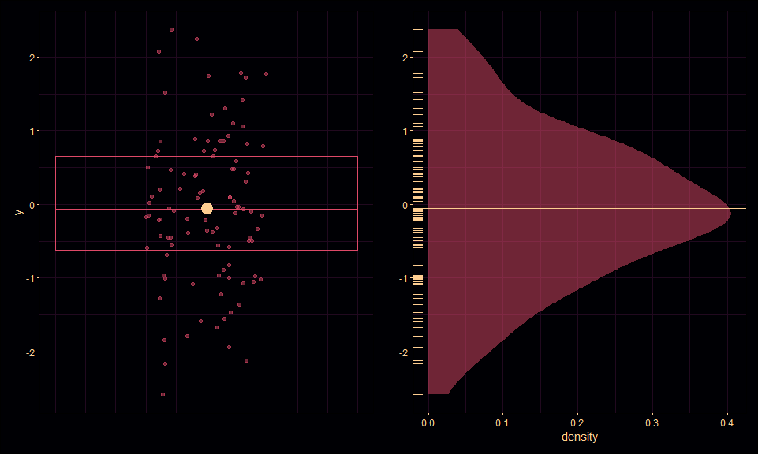

```r
  g1 <- data |>
    ggplot(aes(y = y, x = 1)) +
      geom_jitter(width = 0.1, alpha = 0.5, color = col4) +
      geom_boxplot(fill = NA, width = 0.5, color = col4, outlier.alpha = 0) +
      geom_point(
        data = data |> summarise(y = mean(y)),
        size = 5,
        color = col1
        ) +
      xlab("") +
      theme(
        axis.text.x = element_blank(),
        axis.ticks.x = element_blank()
        )

  g2 <- data |>
    ggplot(aes(x = y)) +
      geom_density(alpha = 0.5, fill = col4) +
      geom_rug(color = col1) +
      geom_vline(
        data = data |> summarise(y = mean(y)),
        aes(xintercept = y), color = col1
        ) +
      coord_flip() +
    # This flips the plot so the Y axes from the g1 and g2 match
      xlab("")
    # Remove this axis label since it's not needed after combining it with g1

# The two plots we just created are then combined using the patchwork package.
# https://patchwork.data-imaginist.com/
  g1 + g2
```

```r
  m1 <- lm(y ~ 1, data = data)
```

```r
  m1
```

```
##
## Call:
## lm(formula = y ~ 1, data = data)
##
## Coefficients:
## (Intercept)
##    -0.05378
```

```r
  mean(data$y)
```

```
## [1] -0.05377657
```

```r
  summary(m1)
```

```
##
## Call:
## lm(formula = y ~ 1, data = data)
##
## Residuals:
##      Min       1Q   Median       3Q      Max
## -2.53112 -0.56335 -0.02325  0.70807  2.42283
##
## Coefficients:
##             Estimate Std. Error t value Pr(>|t|)
## (Intercept) -0.05378    0.10203  -0.527    0.599
##
## Residual standard error: 1.02 on 99 degrees of freedom
```

```r
  sd(data$y) / sqrt(200)
```

```
## [1] 0.07214311
```

```r
  t.test(data$y)
```

```
##
##  One Sample t-test
##
## data:  data$y
## t = -0.52709, df = 99, p-value = 0.5993
## alternative hypothesis: true mean is not equal to 0
## 95 percent confidence interval:
##  -0.2562178  0.1486647
## sample estimates:
##   mean of x
## -0.05377657
```

### Two groups

```r
  set.seed(1207)

  data <- data_frame(
    y = c(rnorm(100, 0, 1), rnorm(100, 1, 1)),
    x = c(rep("Cats", 100), rep("Dogs", 100))
    )

# rep("Cats", 100) repeats "Cats" 100 time (or, more technically, creates a
# character vector of length 100 where every element of the vector is equal to
# "Cats")
```

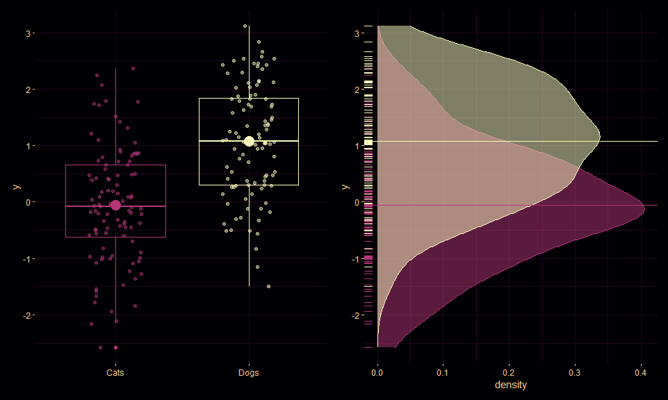

```r
  g1 <- data |>
    ggplot(aes(x = x, y = y, color = x, group = x)) +
      geom_jitter(width = 0.2, alpha = 0.5) +
      geom_boxplot(fill = NA) +
      geom_point(
        data = group_by(data, x) |> summarise(y = mean(y)),
        size = 5
        ) +
      scale_color_viridis(
        guide = "none", option = "A", discrete = TRUE, begin = 0.5
        ) +
      xlab("")

  g2 <- data |>
    ggplot(aes(x = y, fill = x, color = x)) +
      geom_density(alpha = 0.5) +
      geom_rug() +
      geom_vline(
        data = group_by(data, x) |> summarise(y = mean(y)),
        aes(xintercept = y, color = x)
        ) +
      scale_fill_viridis(
        guide = "none", option = "A", discrete = TRUE, begin = 0.5
        ) +
      scale_color_viridis(
        guide = "none", option = "A", discrete = TRUE, begin = 0.5
        ) +
      coord_flip()

  g1 + g2
```

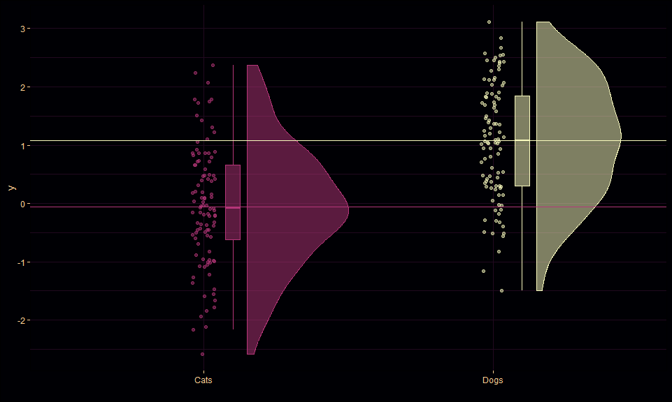

```r
  data |>
  ggplot(aes(x = x, y = y, color = x, group = x, fill = x)) +
    geom_rain(alpha = 0.5) +
    scale_fill_viridis(
      guide = "none", option = "A", discrete = TRUE, begin = 0.5
      ) +
    scale_color_viridis(
      guide = "none", option = "A", discrete = TRUE, begin = 0.5
      ) +
    geom_hline(
      data = group_by(data, x) |> summarise(y = mean(y)),
      aes(yintercept = y, color = x)
      ) +
    xlab("")
```

```r
  t.test(y ~ x, data = data)
```

```
##
##  Welch Two Sample t-test
##
## data:  y by x
## t = -7.9283, df = 197.89, p-value = 1.593e-13
## alternative hypothesis: true difference in means between group Cats and group Dogs is not equal to 0
## 95 percent confidence interval:
##  -1.4121156 -0.8495609
## sample estimates:
## mean in group Cats mean in group Dogs
##        -0.05377657         1.07706167
```

```r
  m2 <- lm(y ~ x, data = data)
```

```r
  summary(m2)
```

```
##
## Call:
## lm(formula = y ~ x, data = data)
##
## Residuals:
##      Min       1Q   Median       3Q      Max
## -2.56902 -0.74211 -0.01378  0.75089  2.42283
##
## Coefficients:
##             Estimate Std. Error t value Pr(>|t|)
## (Intercept) -0.05378    0.10086  -0.533    0.594
## xDogs        1.13084    0.14263   7.928 1.59e-13 ***
## ---
## Signif. codes:  0 '***' 0.001 '**' 0.01 '*' 0.05 '.' 0.1 ' ' 1
##
## Residual standard error: 1.009 on 198 degrees of freedom
## Multiple R-squared:  0.241,  Adjusted R-squared:  0.2371
## F-statistic: 62.86 on 1 and 198 DF,  p-value: 1.59e-13
```

```r
  tidy(m2)
```

| term | estimate | std.error | statistic | p.value |
| --- | --- | --- | --- | --- |
| (Intercept) | -0.05377657 | 0.1008573 | -0.5331944 | 5.944970e-01 |
| xDogs | 1.13083824 | 0.1426338 | 7.9282611 | 1.590171e-13 |

```r
  anova(m2)
```

|  | Df | Sum Sq | Mean Sq | F value | Pr(>F) |
| --- | --- | --- | --- | --- | --- |
| x | 1 | 63.93976 | 63.93976 | 62.85732 | 1.590171e-13 |
| Residuals | 198 | 201.40965 | 1.01722 | NA | NA |

```r
  coefficients(m2)
```

```
## (Intercept)       xDogs
## -0.05377657  1.13083824
```

```r
  confint(m2)
```

```
##                  2.5 %    97.5 %
## (Intercept) -0.2526690 0.1451159
## xDogs        0.8495618 1.4121147
```

```r
  tbl_regression(m2) # Can't include an intercept only model
```

| **Characteristic** | **Beta** | **95% CI**<sup>1</sup> | **p-value** |
| --- | --- | --- | --- |
| x |  |  |  |
| Cats | — | — |  |
| Dogs | 1.1 | 0.85, 1.4 | <0.001 |

<sup>1</sup> CI = Confidence Interval

```r
  tab_model(m1, m2)
```

|  | y |  |  | y |  |  |
| --- | --- | --- | --- | --- | --- | --- |
| Predictors | Estimates | CI | p | Estimates | CI | p |
| (Intercept) | -0.05 | -0.26 – 0.15 | 0.599 | -0.05 | -0.25 – 0.15 | 0.594 |
| x [Dogs] |  |  |  | 1.13 | 0.85 – 1.41 | **<0.001** |
| Observations | 100 |  |  | 200 |  |  |
| R<sup>2</sup> / R<sup>2</sup> adjusted | 0.000 / 0.000 |  |  | 0.241 / 0.237 |  |  |

```r
  predict(m1) |> table()
```

```
##
## -0.0537765725551436
##                 100
```

```r
  mean(data$y)
```

```
## [1] 0.5116425
```

```r
  predict(m2) |> table()
```

```
##
## -0.0537765725551431    1.07706167128403
##                 100                 100
```

```r
  data |> group_by(x) |> summarize(mean_y = mean(y))
```

| x | mean_y |
| --- | --- |
| Cats | -0.05377657 |
| Dogs | 1.07706167 |

### More than two groups

```r
  set.seed(1207)

  data <- data_frame(
    y = c(rnorm(100, 0, 1), rnorm(100, 1, 1), rnorm(100, -0.5, 1)),
    x = factor(c(rep("Cats", 100), rep("Dogs", 100), rep("Fish", 100)))
    )
```

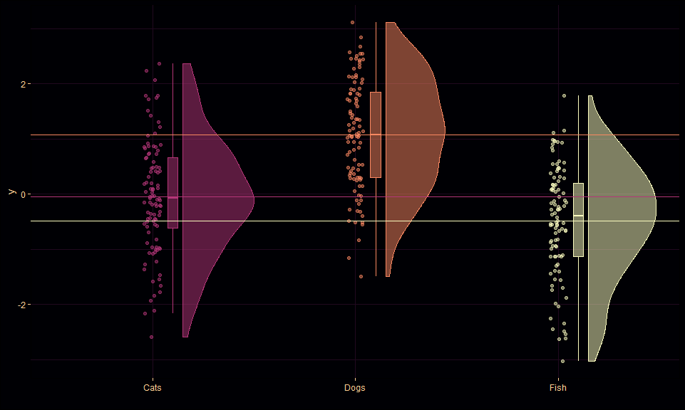

```r
  data |>
  ggplot(aes(x = x, y = y, color = x, group = x, fill = x)) +
    geom_rain(alpha = 0.5) +
    scale_fill_viridis(
      guide = "none", option = "A", discrete = TRUE, begin = 0.5
      ) +
    scale_color_viridis(
      guide = "none", option = "A", discrete = TRUE, begin = 0.5
      ) +
    geom_hline(
      data = group_by(data, x) |> summarise(y = mean(y)),
      aes(yintercept = y, color = x)
      ) +
    xlab("")
```

```r
  lm(y ~ x, data = data) |>
  tab_model()
```

|  | y |  |  |
| --- | --- | --- | --- |
| Predictors | Estimates | CI | p |
| (Intercept) | -0.05 | -0.25 – 0.14 | 0.593 |
| x [Dogs] | 1.13 | 0.85 – 1.41 | **<0.001** |
| x [Fish] | -0.43 | -0.71 – -0.15 | **0.003** |
| Observations | 300 |  |  |
| R<sup>2</sup> / R<sup>2</sup> adjusted | 0.302 / 0.298 |  |  |

```r
  levels(data$x)
```

```
## [1] "Cats" "Dogs" "Fish"
```

```r
  data$x <- relevel(data$x, ref = "Fish")
```

```r
  lm(y ~ x, data = data) |>
  tab_model()
```

|  | y |  |  |
| --- | --- | --- | --- |
| Predictors | Estimates | CI | p |
| (Intercept) | -0.48 | -0.68 – -0.29 | **<0.001** |
| x [Cats] | 0.43 | 0.15 – 0.71 | **0.003** |
| x [Dogs] | 1.56 | 1.28 – 1.84 | **<0.001** |
| Observations | 300 |  |  |
| R<sup>2</sup> / R<sup>2</sup> adjusted | 0.302 / 0.298 |  |  |

```r
  data$x
```

```
##   [1] Cats Cats Cats Cats Cats Cats Cats Cats Cats Cats Cats Cats Cats Cats Cats
##  [16] Cats Cats Cats Cats Cats Cats Cats Cats Cats Cats Cats Cats Cats Cats Cats
##  [31] Cats Cats Cats Cats Cats Cats Cats Cats Cats Cats Cats Cats Cats Cats Cats
##  [46] Cats Cats Cats Cats Cats Cats Cats Cats Cats Cats Cats Cats Cats Cats Cats
##  [61] Cats Cats Cats Cats Cats Cats Cats Cats Cats Cats Cats Cats Cats Cats Cats
##  [76] Cats Cats Cats Cats Cats Cats Cats Cats Cats Cats Cats Cats Cats Cats Cats
##  [91] Cats Cats Cats Cats Cats Cats Cats Cats Cats Cats Dogs Dogs Dogs Dogs Dogs
## [106] Dogs Dogs Dogs Dogs Dogs Dogs Dogs Dogs Dogs Dogs Dogs Dogs Dogs Dogs Dogs
## [121] Dogs Dogs Dogs Dogs Dogs Dogs Dogs Dogs Dogs Dogs Dogs Dogs Dogs Dogs Dogs
## [136] Dogs Dogs Dogs Dogs Dogs Dogs Dogs Dogs Dogs Dogs Dogs Dogs Dogs Dogs Dogs
## [151] Dogs Dogs Dogs Dogs Dogs Dogs Dogs Dogs Dogs Dogs Dogs Dogs Dogs Dogs Dogs
## [166] Dogs Dogs Dogs Dogs Dogs Dogs Dogs Dogs Dogs Dogs Dogs Dogs Dogs Dogs Dogs
## [181] Dogs Dogs Dogs Dogs Dogs Dogs Dogs Dogs Dogs Dogs Dogs Dogs Dogs Dogs Dogs
## [196] Dogs Dogs Dogs Dogs Dogs Fish Fish Fish Fish Fish Fish Fish Fish Fish Fish
## [211] Fish Fish Fish Fish Fish Fish Fish Fish Fish Fish Fish Fish Fish Fish Fish
## [226] Fish Fish Fish Fish Fish Fish Fish Fish Fish Fish Fish Fish Fish Fish Fish
## [241] Fish Fish Fish Fish Fish Fish Fish Fish Fish Fish Fish Fish Fish Fish Fish
## [256] Fish Fish Fish Fish Fish Fish Fish Fish Fish Fish Fish Fish Fish Fish Fish
## [271] Fish Fish Fish Fish Fish Fish Fish Fish Fish Fish Fish Fish Fish Fish Fish
## [286] Fish Fish Fish Fish Fish Fish Fish Fish Fish Fish Fish Fish Fish Fish Fish
## Levels: Fish Cats Dogs
```

```r
  as.character(data$x)
```

```
##   [1] "Cats" "Cats" "Cats" "Cats" "Cats" "Cats" "Cats" "Cats" "Cats" "Cats"
##  [11] "Cats" "Cats" "Cats" "Cats" "Cats" "Cats" "Cats" "Cats" "Cats" "Cats"
##  [21] "Cats" "Cats" "Cats" "Cats" "Cats" "Cats" "Cats" "Cats" "Cats" "Cats"
##  [31] "Cats" "Cats" "Cats" "Cats" "Cats" "Cats" "Cats" "Cats" "Cats" "Cats"
##  [41] "Cats" "Cats" "Cats" "Cats" "Cats" "Cats" "Cats" "Cats" "Cats" "Cats"
##  [51] "Cats" "Cats" "Cats" "Cats" "Cats" "Cats" "Cats" "Cats" "Cats" "Cats"
##  [61] "Cats" "Cats" "Cats" "Cats" "Cats" "Cats" "Cats" "Cats" "Cats" "Cats"
##  [71] "Cats" "Cats" "Cats" "Cats" "Cats" "Cats" "Cats" "Cats" "Cats" "Cats"
##  [81] "Cats" "Cats" "Cats" "Cats" "Cats" "Cats" "Cats" "Cats" "Cats" "Cats"
##  [91] "Cats" "Cats" "Cats" "Cats" "Cats" "Cats" "Cats" "Cats" "Cats" "Cats"
## [101] "Dogs" "Dogs" "Dogs" "Dogs" "Dogs" "Dogs" "Dogs" "Dogs" "Dogs" "Dogs"
## [111] "Dogs" "Dogs" "Dogs" "Dogs" "Dogs" "Dogs" "Dogs" "Dogs" "Dogs" "Dogs"
## [121] "Dogs" "Dogs" "Dogs" "Dogs" "Dogs" "Dogs" "Dogs" "Dogs" "Dogs" "Dogs"
## [131] "Dogs" "Dogs" "Dogs" "Dogs" "Dogs" "Dogs" "Dogs" "Dogs" "Dogs" "Dogs"
## [141] "Dogs" "Dogs" "Dogs" "Dogs" "Dogs" "Dogs" "Dogs" "Dogs" "Dogs" "Dogs"
## [151] "Dogs" "Dogs" "Dogs" "Dogs" "Dogs" "Dogs" "Dogs" "Dogs" "Dogs" "Dogs"
## [161] "Dogs" "Dogs" "Dogs" "Dogs" "Dogs" "Dogs" "Dogs" "Dogs" "Dogs" "Dogs"
## [171] "Dogs" "Dogs" "Dogs" "Dogs" "Dogs" "Dogs" "Dogs" "Dogs" "Dogs" "Dogs"
## [181] "Dogs" "Dogs" "Dogs" "Dogs" "Dogs" "Dogs" "Dogs" "Dogs" "Dogs" "Dogs"
## [191] "Dogs" "Dogs" "Dogs" "Dogs" "Dogs" "Dogs" "Dogs" "Dogs" "Dogs" "Dogs"
## [201] "Fish" "Fish" "Fish" "Fish" "Fish" "Fish" "Fish" "Fish" "Fish" "Fish"
## [211] "Fish" "Fish" "Fish" "Fish" "Fish" "Fish" "Fish" "Fish" "Fish" "Fish"
## [221] "Fish" "Fish" "Fish" "Fish" "Fish" "Fish" "Fish" "Fish" "Fish" "Fish"
## [231] "Fish" "Fish" "Fish" "Fish" "Fish" "Fish" "Fish" "Fish" "Fish" "Fish"
## [241] "Fish" "Fish" "Fish" "Fish" "Fish" "Fish" "Fish" "Fish" "Fish" "Fish"
## [251] "Fish" "Fish" "Fish" "Fish" "Fish" "Fish" "Fish" "Fish" "Fish" "Fish"
## [261] "Fish" "Fish" "Fish" "Fish" "Fish" "Fish" "Fish" "Fish" "Fish" "Fish"
## [271] "Fish" "Fish" "Fish" "Fish" "Fish" "Fish" "Fish" "Fish" "Fish" "Fish"
## [281] "Fish" "Fish" "Fish" "Fish" "Fish" "Fish" "Fish" "Fish" "Fish" "Fish"
## [291] "Fish" "Fish" "Fish" "Fish" "Fish" "Fish" "Fish" "Fish" "Fish" "Fish"
```

```r
  as.numeric(data$x)
```

```
##   [1] 2 2 2 2 2 2 2 2 2 2 2 2 2 2 2 2 2 2 2 2 2 2 2 2 2 2 2 2 2 2 2 2 2 2 2 2 2
##  [38] 2 2 2 2 2 2 2 2 2 2 2 2 2 2 2 2 2 2 2 2 2 2 2 2 2 2 2 2 2 2 2 2 2 2 2 2 2
##  [75] 2 2 2 2 2 2 2 2 2 2 2 2 2 2 2 2 2 2 2 2 2 2 2 2 2 2 3 3 3 3 3 3 3 3 3 3 3
## [112] 3 3 3 3 3 3 3 3 3 3 3 3 3 3 3 3 3 3 3 3 3 3 3 3 3 3 3 3 3 3 3 3 3 3 3 3 3
## [149] 3 3 3 3 3 3 3 3 3 3 3 3 3 3 3 3 3 3 3 3 3 3 3 3 3 3 3 3 3 3 3 3 3 3 3 3 3
## [186] 3 3 3 3 3 3 3 3 3 3 3 3 3 3 3 1 1 1 1 1 1 1 1 1 1 1 1 1 1 1 1 1 1 1 1 1 1
## [223] 1 1 1 1 1 1 1 1 1 1 1 1 1 1 1 1 1 1 1 1 1 1 1 1 1 1 1 1 1 1 1 1 1 1 1 1 1
## [260] 1 1 1 1 1 1 1 1 1 1 1 1 1 1 1 1 1 1 1 1 1 1 1 1 1 1 1 1 1 1 1 1 1 1 1 1 1
## [297] 1 1 1 1
```

```r
  model.matrix(lm(y ~ x, data = data))
```

```
##     (Intercept) xCats xDogs
## 1             1     1     0
## 2             1     1     0
## 3             1     1     0
## 4             1     1     0
## 5             1     1     0
## 6             1     1     0
## 7             1     1     0
## 8             1     1     0
## 9             1     1     0
## 10            1     1     0
## 11            1     1     0
## 12            1     1     0
## 13            1     1     0
## 14            1     1     0
```

[output cut: 291 more lines]

```r
  # Danger!
  # levels(data$x) <- c("Dogs", "Cats", "Fish")

  # lm(y ~ x, data = data) |>
  # tab_model()
```

## Continuous predictors

```r
# Set the seed for the random number generator so you will get the same results
  set.seed(1207)

  data <- rnorm_multi(
    n = 500,
    mu = c(0, 1),
    sd = c(1, 1),
    r = c(0.5),
    varnames = c("x", "y"),
    empirical = FALSE
    )

  data$z <- rnorm(500, 2, 1)
```

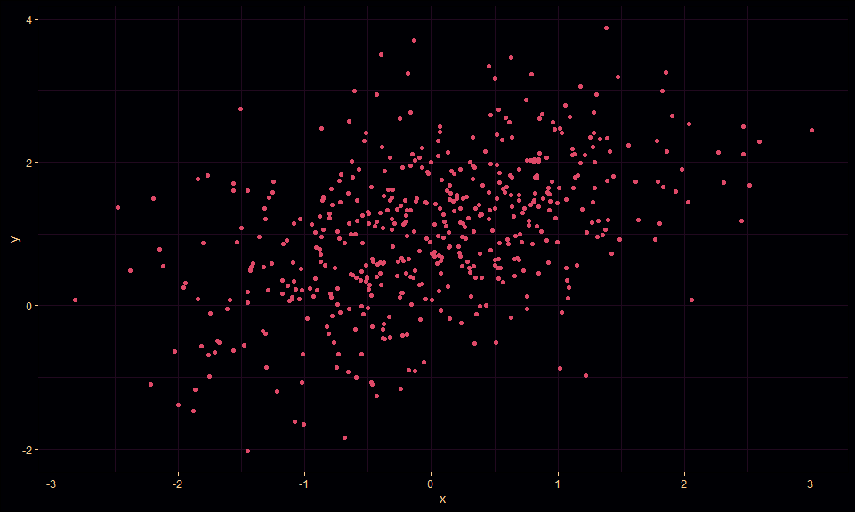

```r
  data |>
  ggplot(aes(x = x, y = y)) +
    geom_point(color = col4)
```

```r
  m1 <- lm(y ~ x, data = data)
```

```r
  tab_model(m1)
```

|  | y |  |  |
| --- | --- | --- | --- |
| Predictors | Estimates | CI | p |
| (Intercept) | 1.04 | 0.96 – 1.11 | **<0.001** |
| x | 0.48 | 0.40 – 0.56 | **<0.001** |
| Observations | 500 |  |  |
| R<sup>2</sup> / R<sup>2</sup> adjusted | 0.217 / 0.215 |  |  |

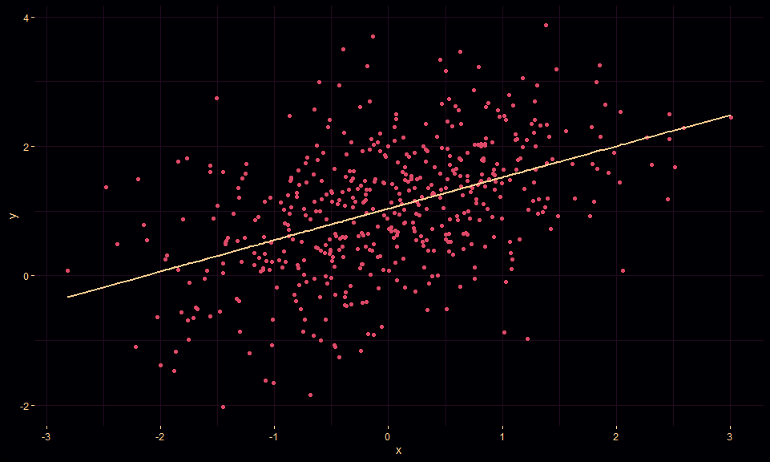

```r
  data$m1_pred <- predict(m1)

  data |>
  ggplot(aes(x = x, y = y)) +
    geom_point(color = col4) +
    geom_line(aes(y = m1_pred), color = col1, size = 1)
```

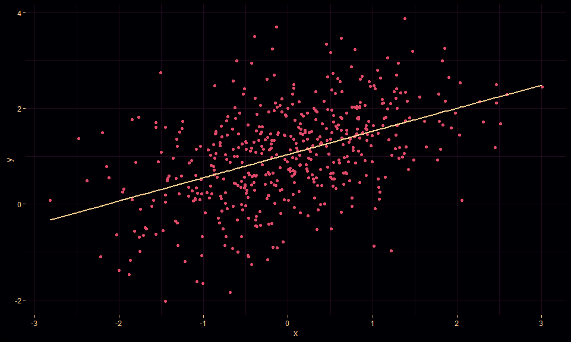

```r
  data |>
  ggplot(aes(x = x, y = y)) +
    geom_point(color = col4) +
    geom_line(aes(y = predict(m1)), color = col1, size = 1)
```

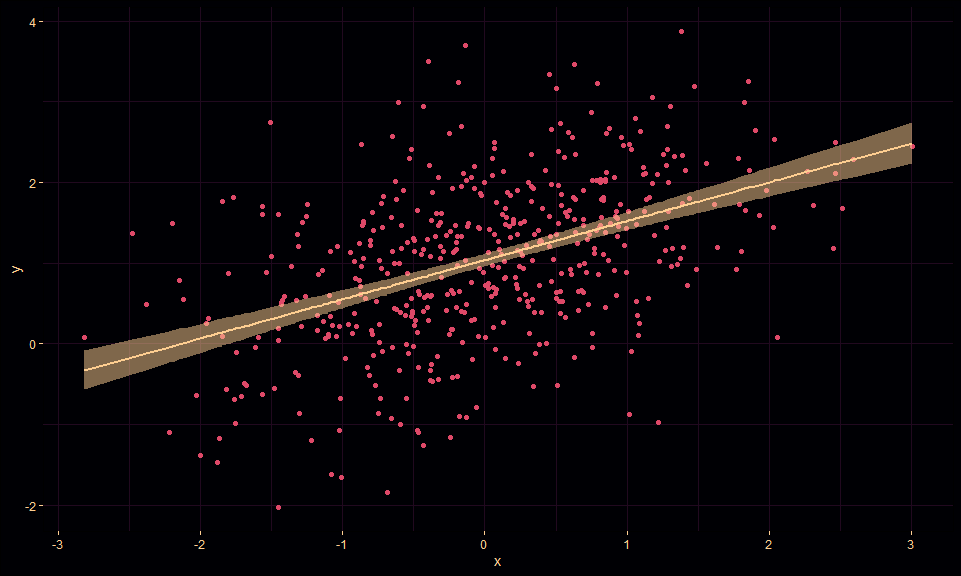

```r
  interval_pred <- as.data.frame(predict(m1, interval = "confidence"))
  interval_pred$x <- data$x

  data |>
  ggplot(aes(x = x)) +
    geom_point(aes(y = y), color = col4) +
    geom_ribbon(
      data = interval_pred,
      aes(ymax = upr, ymin = lwr),
      fill = col1, size = 1, alpha = 0.5
      ) +
    geom_line(aes(y = predict(m1)), color = col1, size = 1)
```

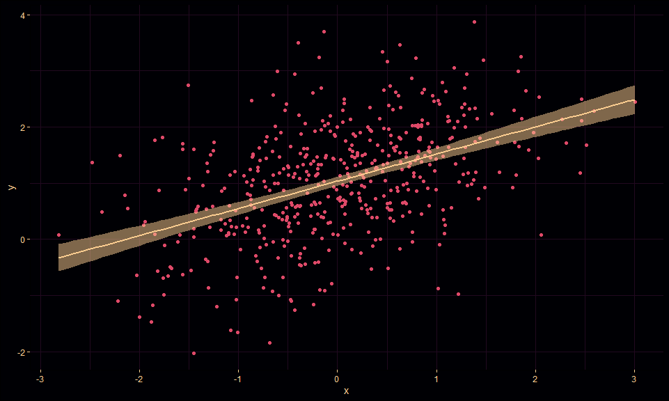

```r
  data |>
  ggplot(aes(x = x, y = y)) +
    geom_point(color = col4) +
    geom_smooth(
      method = "lm", color = col1, fill = col1, alpha = 0.5, size = 1
      )
```

## Categorical and continuous

```r
  set.seed(19347)

  data <- rnorm_multi(
    n = 400,
    mu = c(0, 1),
    sd = c(1, 1),
    r = c(0.5),
    varnames = c("x", "y"),
    empirical = FALSE
    )
  data$group <- sample(c("Cat", "Dog"), size = nrow(data), replace = TRUE)
```

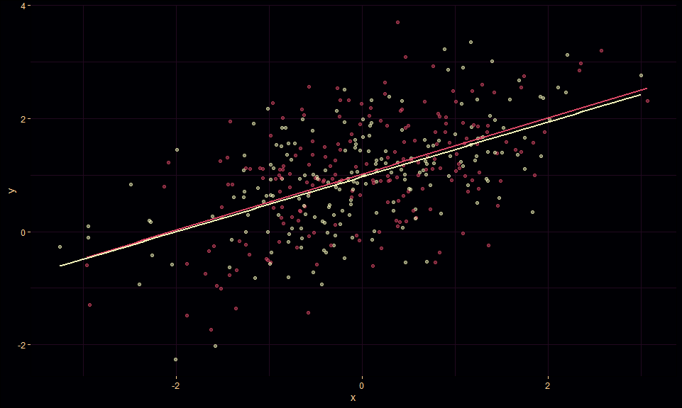

```r
  data |>
  ggplot(aes(x = x, y = y)) +
    geom_point(aes(color = group), alpha = 0.5) +
    scale_color_viridis(
      guide = "none", option = "A", discrete = TRUE, begin = 0.6
      ) +
    geom_smooth(
      aes(group = group, color = group), method = "lm", se = FALSE
      )
```

```r
  lm(y ~ x + group, data = data) |>
  tab_model()
```

|  | y |  |  |
| --- | --- | --- | --- |
| Predictors | Estimates | CI | p |
| (Intercept) | 1.02 | 0.91 – 1.13 | **<0.001** |
| x | 0.49 | 0.42 – 0.57 | **<0.001** |
| group [Dog] | -0.05 | -0.21 – 0.11 | 0.526 |
| Observations | 400 |  |  |
| R<sup>2</sup> / R<sup>2</sup> adjusted | 0.293 / 0.289 |  |  |

```r
  set.seed(19347)

  data <- bind_rows(
    rnorm_multi(
      n = 200,
      mu = c(0, 1),
      sd = c(1, 1),
      r = c(0.5),
      varnames = c("x", "y"),
      empirical = FALSE
      ) |>
      mutate(group = "Cat"),
    rnorm_multi(
        n = 200,
        mu = c(3, 4),
        sd = c(1, 1),
        r = c(0.5),
        varnames = c("x", "y"),
        empirical = FALSE
        ) |>
        mutate(group = "Dog")
    )
```

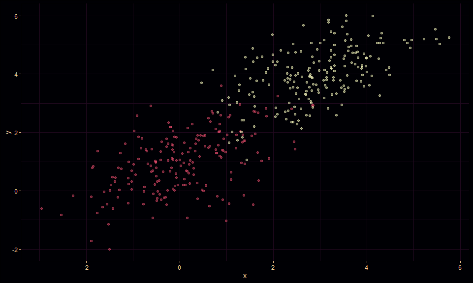

```r
  data |>
  ggplot(aes(x = x, y = y, color = group, group = group)) +
    geom_point(alpha = 0.5) +
    scale_color_viridis(
      guide = "none", option = "A", discrete = TRUE, begin = 0.6
      )
```

```r
  m1 <- lm(y ~ x, data = data)
  m2 <- lm(y ~ x + group, data = data)

  tab_model(m1, m2)
```

|  | y |  |  | y |  |  |
| --- | --- | --- | --- | --- | --- | --- |
| Predictors | Estimates | CI | p | Estimates | CI | p |
| (Intercept) | 1.23 | 1.11 – 1.35 | **<0.001** | 0.98 | 0.87 – 1.10 | **<0.001** |
| x | 0.85 | 0.80 – 0.91 | **<0.001** | 0.51 | 0.43 – 0.59 | **<0.001** |
| group [Dog] |  |  |  | 1.51 | 1.23 – 1.79 | **<0.001** |
| Observations | 400 |  |  | 400 |  |  |
| R<sup>2</sup> / R<sup>2</sup> adjusted | 0.717 / 0.717 |  |  | 0.779 / 0.778 |  |  |

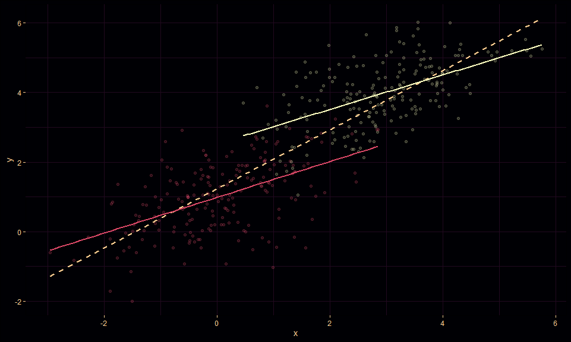

```r
  data |>
  ggplot(aes(x = x, y = y)) +
    geom_point(aes(color = group), alpha = 0.2) +
    scale_color_viridis(
      guide = "none", option = "A", discrete = TRUE, begin = 0.6
      ) +
    geom_smooth(method = "lm", se = FALSE, color = col1, linetype = "dashed") +
    geom_smooth(aes(group = group, color = group), method = "lm", se = FALSE)
```

### Simpson’s paradox

```r
  set.seed(19347)

  data <- bind_rows(
    rnorm_multi(
      n = 200,
      mu = c(0, 1),
      sd = c(1, 1),
      r = c(-0.5),
      varnames = c("x", "y"),
      empirical = FALSE
      ) |>
      mutate(group = "Cat"),
    rnorm_multi(
        n = 200,
        mu = c(3, 4),
        sd = c(1, 1),
        r = c(-0.5),
        varnames = c("x", "y"),
        empirical = FALSE
        ) |>
        mutate(group = "Dog")
    )
```

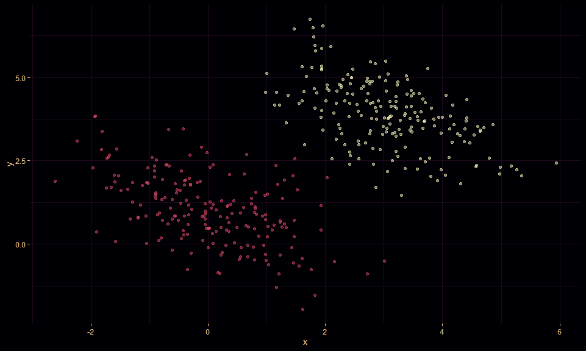

```r
  g1 <- data |>
  ggplot(aes(x = x, y = y, color = group)) +
    geom_point(alpha = 0.5) +
    scale_color_viridis(
      guide = "none", option = "A", discrete = TRUE, begin = 0.6
      )

  g1
```

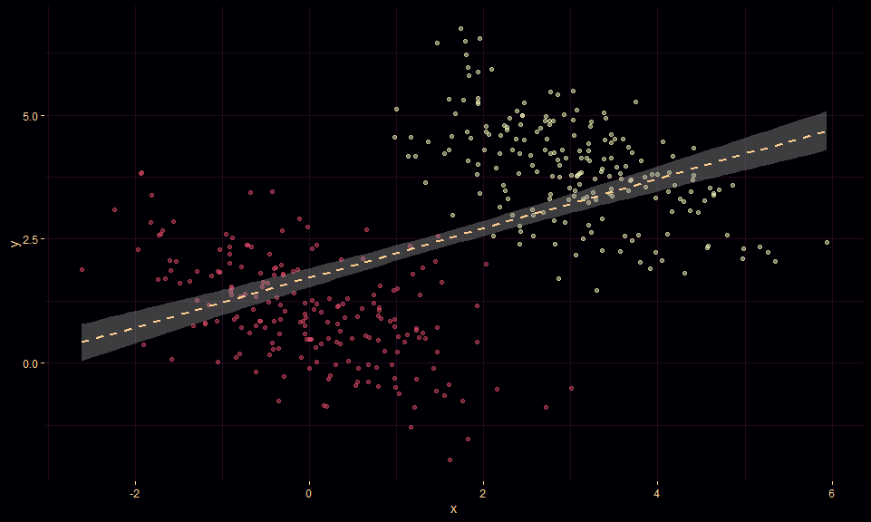

```r
  g1 + geom_smooth(method = "lm", color = col1, linetype = "dashed")
```

```r
  m1 <- lm(y ~ x,         data = data)
  m2 <- lm(y ~ group,     data = data)
  m3 <- lm(y ~ x + group, data = data)

  tab_model(m1, m2, m3)
```

|  | y |  |  | y |  |  | y |  |  |
| --- | --- | --- | --- | --- | --- | --- | --- | --- | --- |
| Predictors | Estimates | CI | p | Estimates | CI | p | Estimates | CI | p |
| (Intercept) | 1.72 | 1.53 – 1.92 | **<0.001** | 1.04 | 0.90 – 1.19 | **<0.001** | 1.04 | 0.92 – 1.16 | **<0.001** |
| x | 0.50 | 0.42 – 0.58 | **<0.001** |  |  |  | -0.56 | -0.64 – -0.47 | **<0.001** |
| group [Dog] |  |  |  | 2.87 | 2.66 – 3.07 | **<0.001** | 4.56 | 4.24 – 4.87 | **<0.001** |
| Observations | 400 |  |  | 400 |  |  | 400 |  |  |
| R<sup>2</sup> / R<sup>2</sup> adjusted | 0.261 / 0.259 |  |  | 0.658 / 0.657 |  |  | 0.754 / 0.753 |  |  |

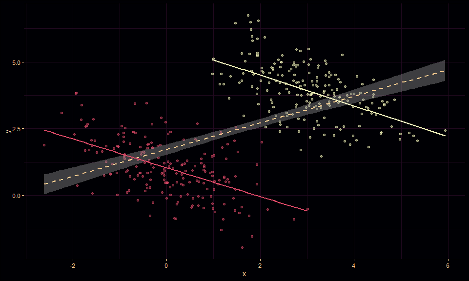

```r
  g1 +
    geom_smooth(method = "lm", color = col1, linetype = "dashed") +
    geom_smooth(aes(group = group, color = group), method = "lm", se = FALSE)
```

```r
  m_res <- lm(x ~ group, data = data) # X regressed on group
  data$residual <- residuals(m_res) # Variation in X not explained by group

  m4 <- lm(y ~ residual, data = data)
  tab_model(m1, m2, m3, m4, m_res)
```

|  | y |  |  | y |  |  | y |  |  | y |  |  | x |  |  |
| --- | --- | --- | --- | --- | --- | --- | --- | --- | --- | --- | --- | --- | --- | --- | --- |
| Predictors | Estimates | CI | p | Estimates | CI | p | Estimates | CI | p | Estimates | CI | p | Estimates | CI | p |
| (Intercept) | 1.72 | 1.53 – 1.92 | **<0.001** | 1.04 | 0.90 – 1.19 | **<0.001** | 1.04 | 0.92 – 1.16 | **<0.001** | 2.48 | 2.31 – 2.64 | **<0.001** | -0.01 | -0.14 – 0.13 | 0.930 |
| x | 0.50 | 0.42 – 0.58 | **<0.001** |  |  |  | -0.56 | -0.64 – -0.47 | **<0.001** |  |  |  |  |  |  |
| group [Dog] |  |  |  | 2.87 | 2.66 – 3.07 | **<0.001** | 4.56 | 4.24 – 4.87 | **<0.001** |  |  |  | 3.04 | 2.84 – 3.23 | **<0.001** |
| residual |  |  |  |  |  |  |  |  |  | -0.56 | -0.72 – -0.39 | **<0.001** |  |  |  |
| Observations | 400 |  |  | 400 |  |  | 400 |  |  | 400 |  |  | 400 |  |  |
| R<sup>2</sup> / R<sup>2</sup> adjusted | 0.261 / 0.259 |  |  | 0.658 / 0.657 |  |  | 0.754 / 0.753 |  |  | 0.096 / 0.094 |  |  | 0.703 / 0.703 |  |  |

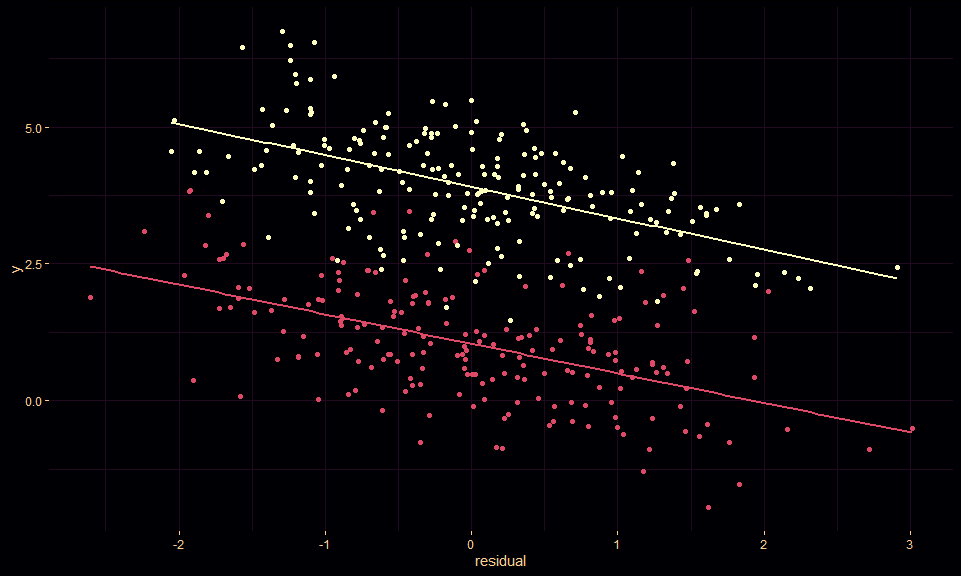

```r
  ggplot(data, aes(y = y, x = residual)) +
    geom_point(aes(color = group)) +
    geom_smooth(aes(color = group), method = "lm", se = FALSE) +
    scale_color_viridis(
      guide = "none", option = "A", discrete = TRUE, begin = 0.6
      )
```

## Interaction

```r
  set.seed(19347)

  data <- bind_rows(
    rnorm_multi(
      n = 200,
      mu = c(0, 1),
      sd = c(1, 1),
      r = c(0.5),
      varnames = c("x", "y"),
      empirical = FALSE
      ) |>
      mutate(group = "Cat"),
    rnorm_multi(
        n = 200,
        mu = c(3, 4),
        sd = c(1, 1),
        r = c(-0.5),
        varnames = c("x", "y"),
        empirical = FALSE
        ) |>
        mutate(group = "Dog")
    )
```

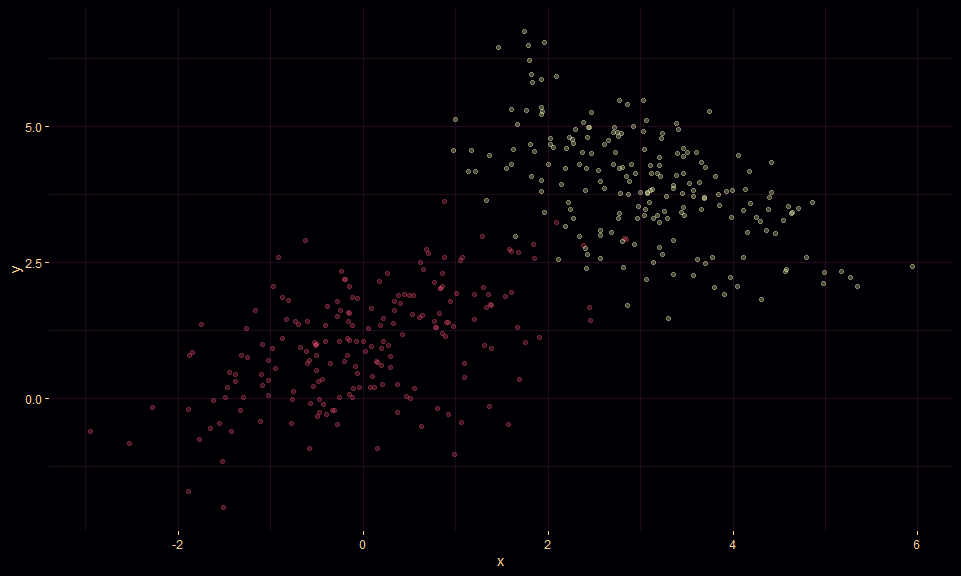

```r
  g1 <- data |>
  ggplot(aes(x = x, y = y, color = group)) +
    geom_point(alpha = 0.3) +
    scale_color_viridis(
      guide = "none", option = "A", discrete = TRUE, begin = 0.6
      )

  g1
```

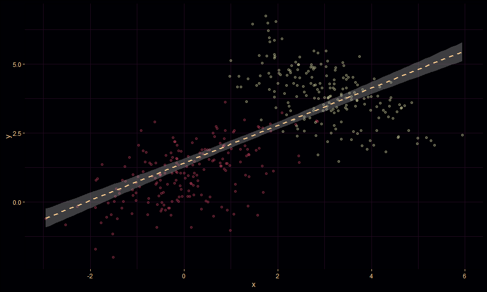

```r
  g1 + geom_smooth(method = "lm", color = col1, linetype = "dashed")
```

```r
  m1 <- lm(y ~ x, data = data)
  m2 <- lm(y ~ x + group, data = data)
  m3 <- lm(y ~ x * group, data = data)

  tab_model(m1, m2, m3)
```

|  | y |  |  | y |  |  | y |  |  |
| --- | --- | --- | --- | --- | --- | --- | --- | --- | --- |
| Predictors | Estimates | CI | p | Estimates | CI | p | Estimates | CI | p |
| (Intercept) | 1.41 | 1.25 – 1.58 | **<0.001** | 1.01 | 0.86 – 1.15 | **<0.001** | 0.98 | 0.86 – 1.11 | **<0.001** |
| x | 0.68 | 0.61 – 0.75 | **<0.001** | 0.03 | -0.08 – 0.13 | 0.619 | 0.52 | 0.40 – 0.63 | **<0.001** |
| group [Dog] |  |  |  | 2.83 | 2.46 – 3.19 | **<0.001** | 4.67 | 4.24 – 5.09 | **<0.001** |
| x × group [Dog] |  |  |  |  |  |  | -1.09 | -1.26 – -0.92 | **<0.001** |
| Observations | 400 |  |  | 400 |  |  | 400 |  |  |
| R<sup>2</sup> / R<sup>2</sup> adjusted | 0.473 / 0.472 |  |  | 0.669 / 0.667 |  |  | 0.762 / 0.760 |  |  |

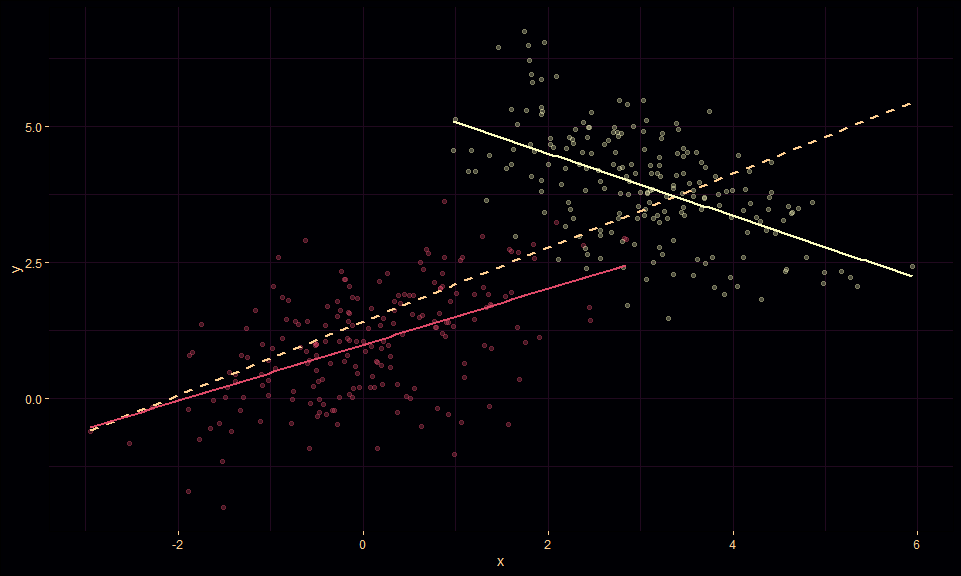

```r
  g1 +
    geom_smooth(method = "lm", color = col1, linetype = "dashed", se = FALSE) +
    geom_smooth(aes(group = group, color = group), method = "lm", se = FALSE)
```

```r
  test_performance(m1, m2, m3)
```

| Name | Model | log_BF | BF | df | df_diff | Chi2 | p |
| --- | --- | --- | --- | --- | --- | --- | --- |
| m1 | lm | NA | NA | 3 | NA | NA | NA |
| m2 | lm | 89.92177 | 1.128568e+39 | 4 | 1 | 185.8350 | 2.579361e-42 |
| m3 | lm | 63.05957 | 2.434572e+27 | 5 | 1 | 132.1106 | 1.415113e-30 |

## Other issues and topics

### Mean centering

```r
  set.seed(19347)

  data <- rnorm_multi(
    n = 400,
    mu = c(3,   1),
    sd = c(0.5, 1),
    r = c(0.5),
    varnames = c("x", "y"),
    empirical = FALSE
    )
```

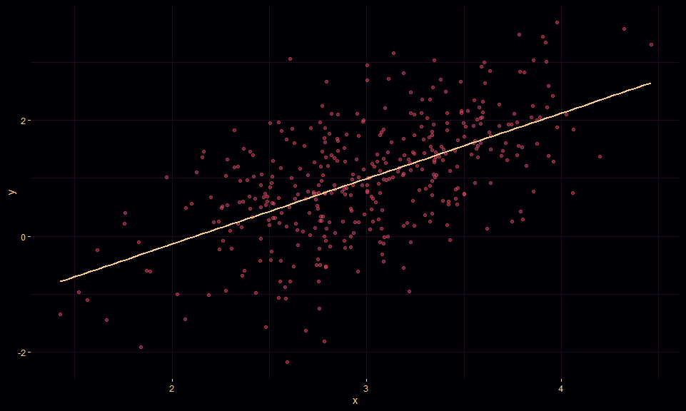

```r
  data |>
  ggplot(aes(x = x, y = y)) +
    geom_point(alpha = 0.5, color = col4) +
    geom_smooth(method = "lm", se = FALSE, color = col1)
```

```r
  lm(y ~ x, data = data) |>
  tab_model()
```

|  | y |  |  |
| --- | --- | --- | --- |
| Predictors | Estimates | CI | p |
| (Intercept) | -2.39 | -2.86 – -1.92 | **<0.001** |
| x | 1.13 | 0.97 – 1.28 | **<0.001** |
| Observations | 400 |  |  |
| R<sup>2</sup> / R<sup>2</sup> adjusted | 0.340 / 0.338 |  |  |

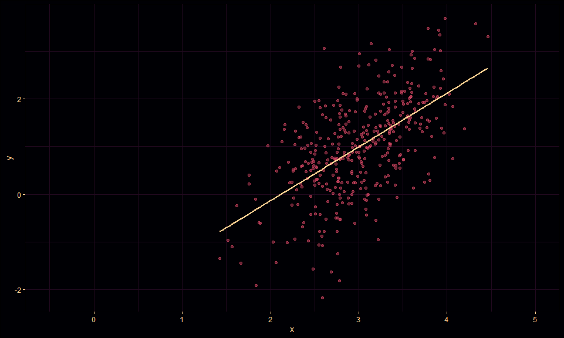

```r
  data |>
  ggplot(aes(x = x, y = y)) +
    geom_point(alpha = 0.5, color = col4) +
    geom_smooth(method = "lm", se = FALSE, color = col1) +
    scale_x_continuous(limits = c(-0.5, 5))
```

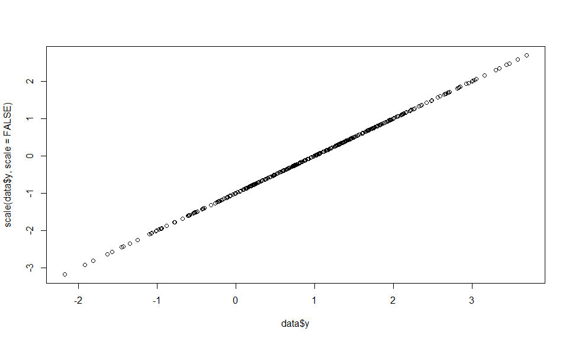

```r
  plot(data$y, scale(data$y, scale = FALSE))
```

```r
  lm(y ~ scale(x, scale = FALSE), data = data) |>
  tab_model()
```

|  | y |  |  |
| --- | --- | --- | --- |
| Predictors | Estimates | CI | p |
| (Intercept) | 1.00 | 0.91 – 1.08 | **<0.001** |
| x | 1.13 | 0.97 – 1.28 | **<0.001** |
| Observations | 400 |  |  |
| R<sup>2</sup> / R<sup>2</sup> adjusted | 0.340 / 0.338 |  |  |

### What do we assume is normally distributed?

```r
  set.seed(1207)

  data <- data_frame(
    y = c(rnorm(100, 0, 1), rnorm(100, 4, 1)),
    x = c(rep("Cats", 100), rep("Dogs", 100))
    )
```

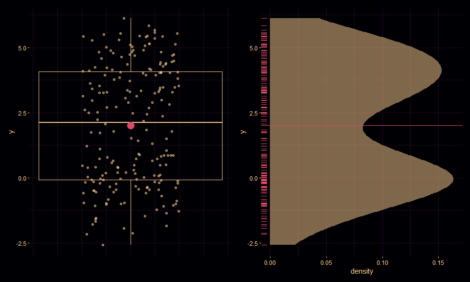

```r
  g1 <- data |>
    ggplot(aes(y = y, x = 1)) +
      geom_jitter(width = 0.2, alpha = 0.5, color = col1) +
      geom_boxplot(fill = NA, color = col1) +
      geom_point(
        data = data |> summarise(y = mean(y)),
        size = 5,
        color = col4
        ) +
      xlab("") +
      theme(
        axis.text.x = element_blank(),
        axis.ticks.x = element_blank()
        )

  g2 <- data |>
    ggplot(aes(x = y)) +
      geom_density(alpha = 0.5, fill = col1) +
      geom_rug(color = col4) +
      geom_vline(
        data = data |> summarise(y = mean(y)),
        aes(xintercept = y), color = col4
        ) +
      coord_flip()

  g1 + g2
```

```r
  m1 <- lm(y ~ 1, data = data)
  m2 <- lm(y ~ x, data = data)
```

```r
  tab_model(m1, m2)
```

|  | y |  |  | y |  |  |
| --- | --- | --- | --- | --- | --- | --- |
| Predictors | Estimates | CI | p | Estimates | CI | p |
| (Intercept) | 2.01 | 1.69 – 2.33 | **<0.001** | -0.05 | -0.25 – 0.15 | 0.594 |
| x [Dogs] |  |  |  | 4.13 | 3.85 – 4.41 | **<0.001** |
| Observations | 200 |  |  | 200 |  |  |
| R<sup>2</sup> / R<sup>2</sup> adjusted | 0.000 / 0.000 |  |  | 0.809 / 0.808 |  |  |

```r
  check_model(m1, check = "normality")
```

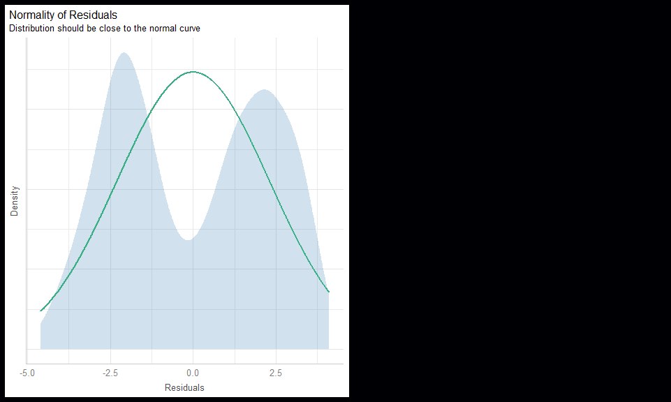

```r
  check_model(m2, check = "normality")
```

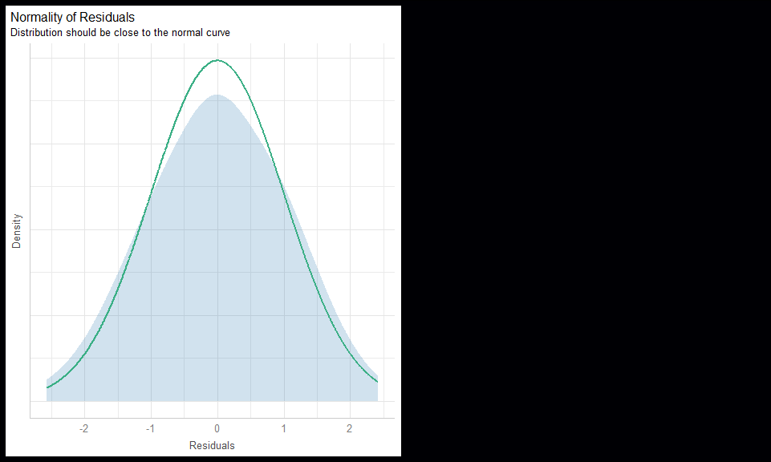

### Log transformations

#### Example 1

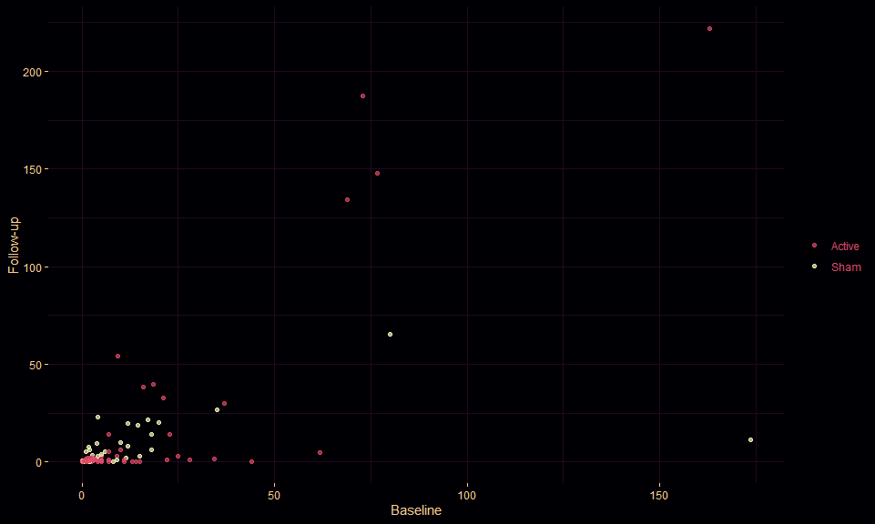

```r
  data <- read_csv("data/log_example.csv") |>
    na.omit()
  data$fu6mo_pad <- data$fu6mo_pad + 0.01
  data$b_pad <- data$b_pad + 0.01

  g1 <- data |>
  ggplot(aes(x = b_pad, y = fu6mo_pad, color = active)) +
    geom_point(alpha = 0.7) +
    scale_color_viridis(
      "", option = "A", discrete = TRUE, begin = 0.6
      ) +
    xlab("Baseline") +
    ylab("Follow-up")

  g1
```

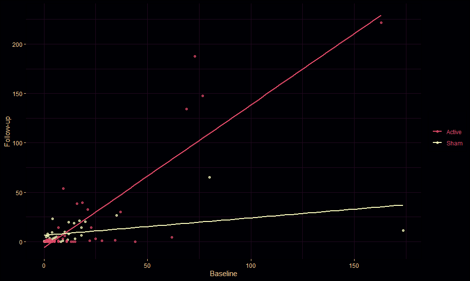

```r
  g1 + geom_smooth(method = "lm", se = FALSE)
```

```r
  m1a <- lm(fu6mo_pad ~ active,         data = data)
  m2a <- lm(fu6mo_pad ~ active + b_pad, data = data)
  m3a <- lm(fu6mo_pad ~ active * b_pad, data = data)

  tab_model(m1a, m2a, m3a)
```

|  | fu 6 mo pad |  |  | fu 6 mo pad |  |  | fu 6 mo pad |  |  |
| --- | --- | --- | --- | --- | --- | --- | --- | --- | --- |
| Predictors | Estimates | CI | p | Estimates | CI | p | Estimates | CI | p |
| (Intercept) | 17.15 | 7.22 – 27.08 | **0.001** | 2.96 | -4.95 – 10.86 | 0.459 | -6.10 | -12.29 – 0.10 | 0.054 |
| active [Sham] | -8.15 | -24.45 – 8.15 | 0.323 | -7.15 | -19.03 – 4.73 | 0.235 | 12.46 | 2.59 – 22.32 | **0.014** |
| b pad |  |  |  | 0.88 | 0.68 – 1.08 | **<0.001** | 1.45 | 1.25 – 1.64 | **<0.001** |
| active [Sham] × b pad |  |  |  |  |  |  | -1.27 | -1.56 – -0.97 | **<0.001** |
| Observations | 89 |  |  | 89 |  |  | 89 |  |  |
| R<sup>2</sup> / R<sup>2</sup> adjusted | 0.011 / -0.000 |  |  | 0.482 / 0.470 |  |  | 0.722 / 0.712 |  |  |

```r
  test_performance(m1a, m2a, m3a)
```

| Name | Model | log_BF | BF | df | df_diff | Chi2 | p |
| --- | --- | --- | --- | --- | --- | --- | --- |
| m1a | lm | NA | NA | 3 | NA | NA | NA |
| m2a | lm | 26.48779 | 318787160236 | 4 | 1 | 57.46422 | 3.441846e-14 |
| m3a | lm | 25.42749 | 110412958627 | 5 | 1 | 55.34362 | 1.011976e-13 |

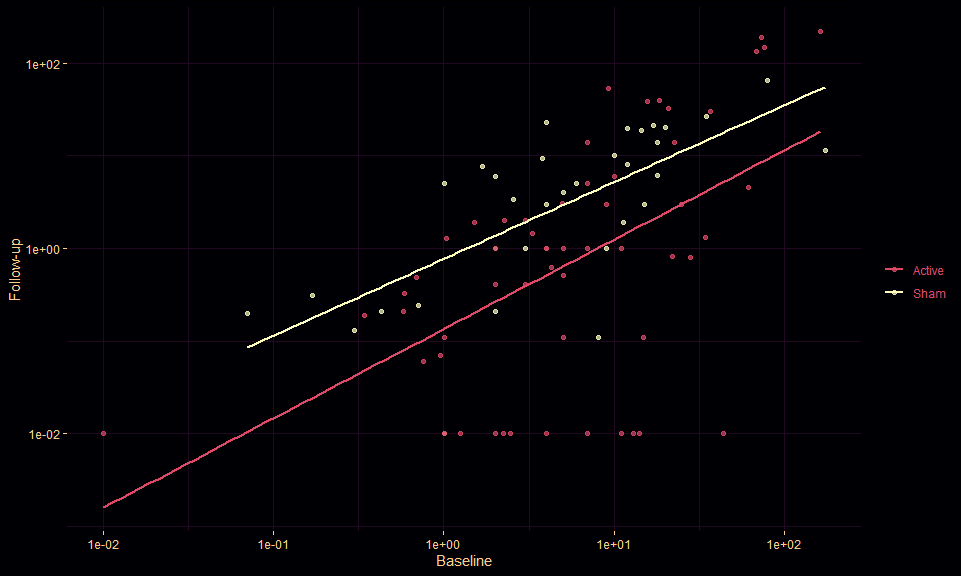

```r
  g1 <- data |>
  ggplot(aes(x = b_pad, y = fu6mo_pad, color = active)) +
    geom_point(alpha = 0.7) +
    scale_color_viridis(
      "", option = "A", discrete = TRUE, begin = 0.6
      ) +
    xlab("Baseline") +
    ylab("Follow-up") +
    scale_y_log10() +
    scale_x_log10() +
    geom_smooth(method = "lm", se = FALSE)

  g1
```

```r
  m1b <- lm(log(fu6mo_pad) ~ active,              data = data)
  m2b <- lm(log(fu6mo_pad) ~ active + log(b_pad), data = data)
  m3b <- lm(log(fu6mo_pad) ~ active * log(b_pad), data = data)

  tab_model(m1b, m2b, m3b)
```

|  | log(fu 6 mo pad) |  |  | log(fu 6 mo pad) |  |  | log(fu 6 mo pad) |  |  |
| --- | --- | --- | --- | --- | --- | --- | --- | --- | --- |
| Predictors | Estimates | CI | p | Estimates | CI | p | Estimates | CI | p |
| (Intercept) | -0.37 | -1.07 – 0.34 | 0.307 | -1.92 | -2.66 – -1.17 | **<0.001** | -2.00 | -2.84 – -1.17 | **<0.001** |
| active [Sham] | 1.35 | 0.19 – 2.51 | **0.023** | 1.53 | 0.57 – 2.49 | **0.002** | 1.74 | 0.43 – 3.06 | **0.010** |
| b pad [log] |  |  |  | 0.91 | 0.64 – 1.19 | **<0.001** | 0.96 | 0.61 – 1.32 | **<0.001** |
| active [Sham] × b pad [log] |  |  |  |  |  |  | -0.14 | -0.71 – 0.44 | 0.640 |
| Observations | 89 |  |  | 89 |  |  | 89 |  |  |
| R<sup>2</sup> / R<sup>2</sup> adjusted | 0.058 / 0.047 |  |  | 0.372 / 0.358 |  |  | 0.374 / 0.352 |  |  |

```r
  test_performance(m1b, m2b, m3b)
```

| Name | Model | log_BF | BF | df | df_diff | Chi2 | p |
| --- | --- | --- | --- | --- | --- | --- | --- |
| m1b | lm | NA | NA | 3 | NA | NA | NA |
| m2b | lm | 15.833964 | 7.526677e+06 | 4 | 1 | 36.1565648 | 1.820840e-09 |
| m3b | lm | -2.129113 | 1.189428e-01 | 5 | 1 | 0.2304104 | 6.312197e-01 |

```r
  check_model(m2a)
```

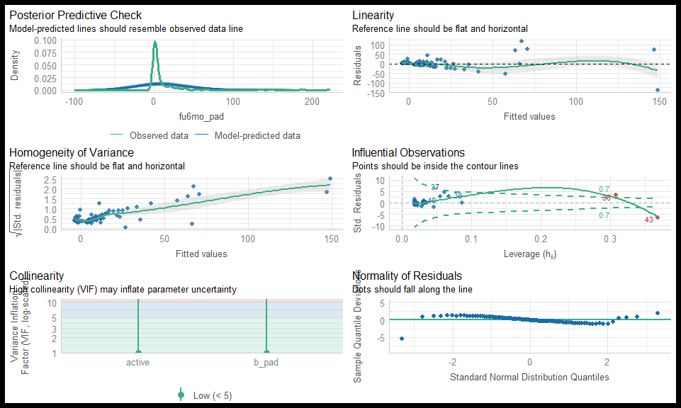

```r
  check_model(m2b)
```

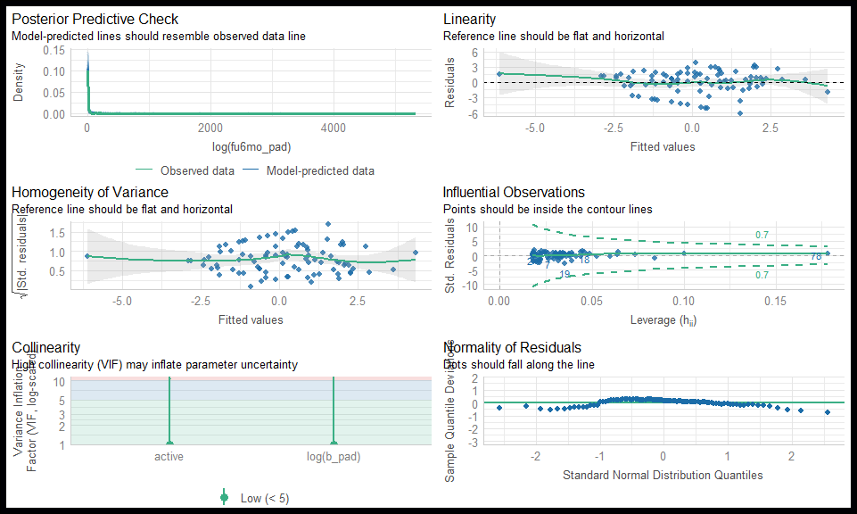

#### Example 2

```r
   data <- read_csv("data/steps.csv")
```

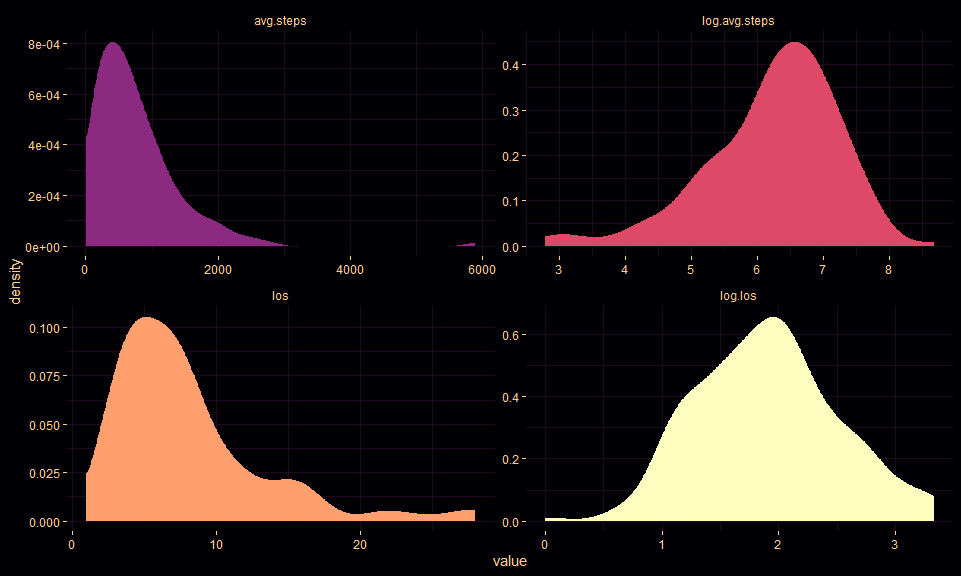

```r
  data |>
    pivot_longer(-id, names_to = "variable", values_to = "value") |>
    mutate(variable = factor(
      variable,
      levels = c("avg.steps", "log.avg.steps", "los", "log.los")
      )) |>
  ggplot(aes(x = value, fill = variable)) +
    geom_density() +
    geom_rug() +
    scale_fill_viridis(
      guide = "none", begin = 0.4, option = "A", discrete = TRUE
      ) +
    facet_wrap(~variable, scales = "free")
```

```r
  m1 <- lm(los ~ avg.steps, data)

  summary(m1)
```

```
##
## Call:
## lm(formula = los ~ avg.steps, data = data)
##
## Residuals:
##    Min     1Q Median     3Q    Max
## -7.632 -3.650 -1.227  1.623 19.275
##
## Coefficients:
##               Estimate Std. Error t value Pr(>|t|)
## (Intercept)  9.4672380  0.6484016  14.601  < 2e-16 ***
## avg.steps   -0.0017605  0.0006241  -2.821  0.00546 **
## ---
## Signif. codes:  0 '***' 0.001 '**' 0.01 '*' 0.05 '.' 0.1 ' ' 1
##
## Residual standard error: 5.342 on 146 degrees of freedom
##   (6 observations deleted due to missingness)
## Multiple R-squared:  0.05168,    Adjusted R-squared:  0.04518
## F-statistic: 7.956 on 1 and 146 DF,  p-value: 0.00546
```

```r
  check_model(m1)
```

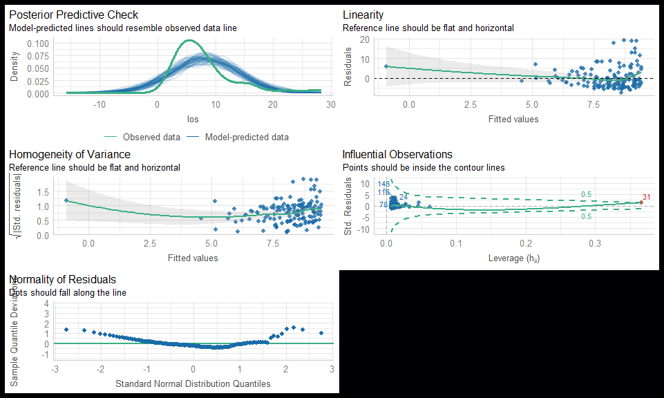

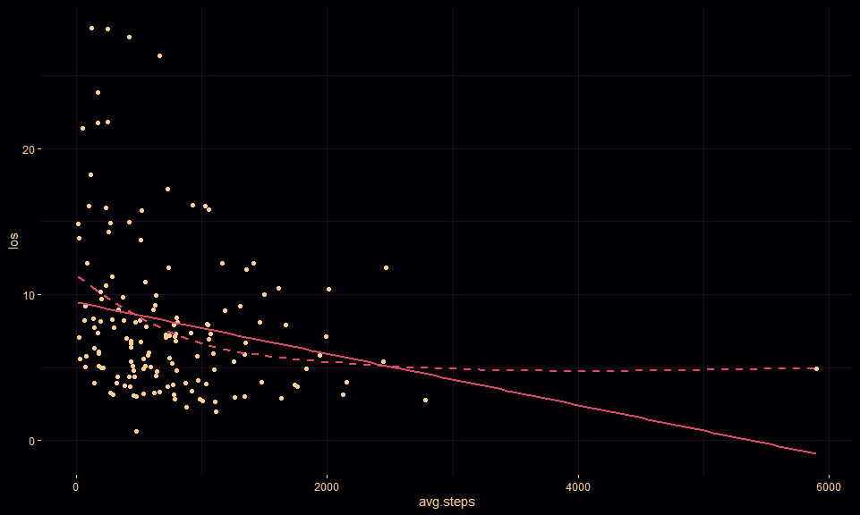

```r
  ggplot(data, aes(x = avg.steps, y = los)) +
    geom_jitter(color = col1) +
    geom_smooth(method = "lm", color = col4,   se = FALSE) +
    geom_smooth(
      span   = 1, color = col4, se = FALSE,
      linetype = "dashed"
      )
```

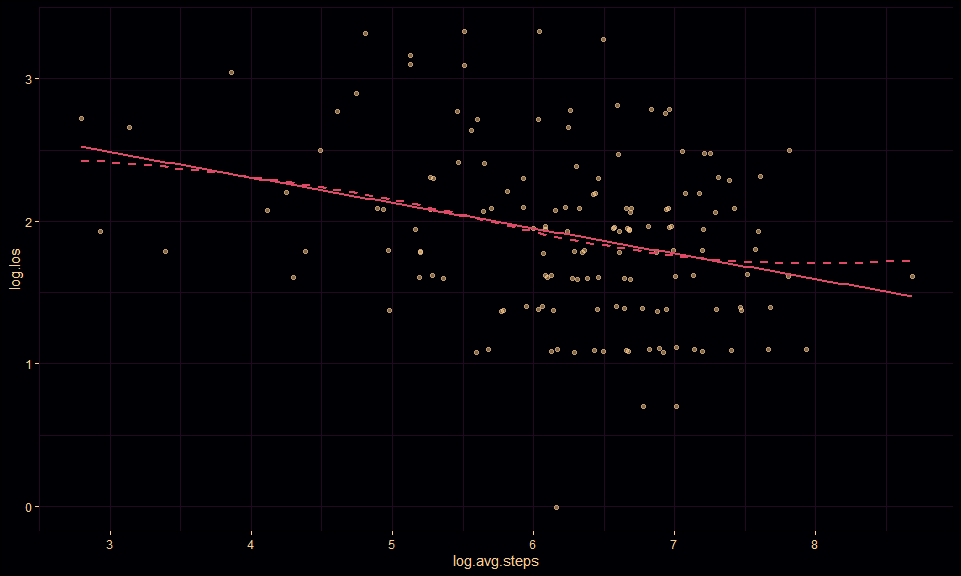

```r
  ggplot(data, aes(x = log.avg.steps, y = log.los, group)) +
    geom_jitter(alpha = 0.5, color = col1) +
    geom_smooth(method = "lm", color = col4,   se = FALSE) +
    geom_smooth(
      span = 1, color = col4, se = FALSE, linetype = "dashed"
      )
```

```r
  m2 <- lm(log.los ~ log.avg.steps, data)

  summary(m2)
```

```
##
## Call:
## lm(formula = log.los ~ log.avg.steps, data = data)
##
## Residuals:
##      Min       1Q   Median       3Q      Max
## -1.92304 -0.44851  0.00306  0.32693  1.39440
##
## Coefficients:
##               Estimate Std. Error t value Pr(>|t|)
## (Intercept)    3.01997    0.29400  10.272  < 2e-16 ***
## log.avg.steps -0.17800    0.04653  -3.825 0.000193 ***
## ---
## Signif. codes:  0 '***' 0.001 '**' 0.01 '*' 0.05 '.' 0.1 ' ' 1
##
## Residual standard error: 0.5748 on 146 degrees of freedom
##   (6 observations deleted due to missingness)
## Multiple R-squared:  0.09109,    Adjusted R-squared:  0.08486
## F-statistic: 14.63 on 1 and 146 DF,  p-value: 0.0001931
```

```r
  check_model(m2)
```

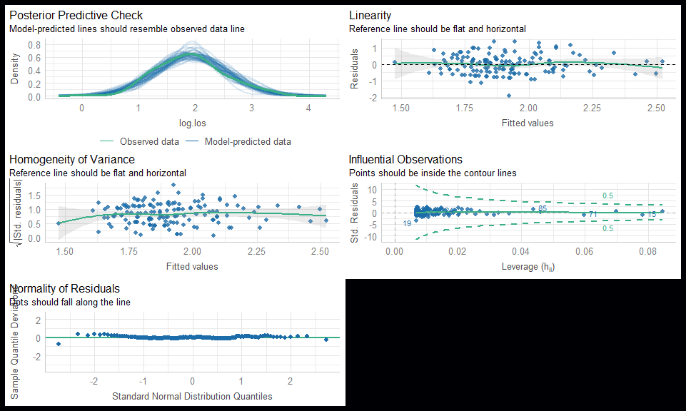

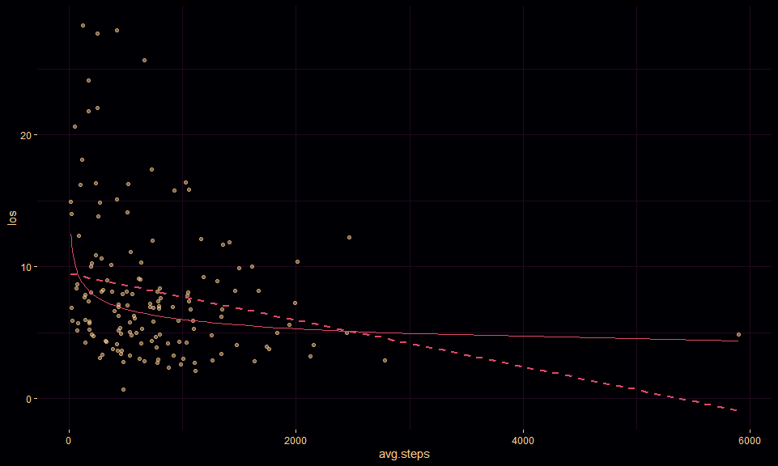

```r
  ggplot(data, aes(x = avg.steps, y = los)) +
    geom_jitter(alpha = 0.5, color = col1) +
    geom_smooth(method = "lm", color = col4, se = FALSE, linetype = "dashed") +
    geom_line(
      data = data.frame(x = exp(m2$model$log.avg.steps), y = exp(predict(m2))),
      aes(x = x, y = y),
      color = col4, size = 0.7
      )
```

```r
  DescTools::SysInfo()
```

```
##
## System: Windows 10 x64 build 19045
## Nodename: DESKTOP-JKQ7LTN, User: Darren
```

```
##
## Total Memory: Inf MB
##
## R version 4.4.1 (2024-06-14 ucrt)
## x86_64-w64-mingw32/x64
##
## Loaded Packages:
##  faux (1.2.1), broom (1.0.6), lmtest (0.9-40), zoo (1.8-12), performance (0.12.3), ggrain (0.0.4), patchwork (1.3.0), sjPlot (2.8.16), gtsummary (2.0.2), knitr (1.48), viridis (0.6.5), viridisLite (0.4.2), lubridate (1.9.3), forcats (1.0.0), stringr (1.5.1), dplyr (1.1.4), purrr (1.0.2), readr (2…
```